# Trabajo Final: IBreakdown con RandomForest en Dataset Properaty

Renso Gil y Leandro Morinigo

04/12/2022

### Carga de librerías y datasets

#### Librerías a utiliza

```r
library(tidyverse)
library(tidymodels)
library(rsample)
library(ggplot2)
library(GGally)
library(fastDummies)
library("stringr")
require(data.table)

#Libreria Random Forest
library(randomForest)

# Librerías BreakDown
library(DALEX)
library(iBreakDown)
```

### Cargar archivo

Se utiliza el dataset ya procesado en la cátedra de EEA : https://github.com/eea-uba/EEA-2022

```r
datos_properati <- read.csv("properati_preprocesado_2022.csv")
# creamos nueva variable de superficie descubierta

datos_properati = datos_properati %>%
  mutate(surface_uncovered = surface_total - surface_covered)

glimpse(datos_properati)
```

```
## Rows: 28,773
## Columns: 10
## $ id                <chr> "1ZHYJgyAbGUcX+v1Ggj1rA==", "BcAHh7UMLQpQ/axyyuwqkQ=…
## $ l3                <chr> "Palermo", "Caballito", "Flores", "Flores", "Retiro"…
## $ rooms             <int> 1, 1, 1, 1, 1, 1, 1, 1, 1, 1, 1, 1, 1, 1, 1, 1, 1, 1…
## $ bathrooms         <int> 1, 1, 1, 1, 1, 1, 1, 1, 1, 1, 1, 1, 1, 1, 1, 1, 1, 1…
## $ surface_total     <int> 38, 55, 37, 37, 29, 41, 36, 31, 30, 36, 32, 34, 27, …
## $ surface_covered   <int> 35, 36, 32, 33, 26, 38, 32, 29, 28, 33, 32, 27, 27, …
## $ price             <int> 125000, 74500, 79900, 53700, 57000, 99000, 93000, 68…
## $ property_type     <chr> "Departamento", "Departamento", "Departamento", "Dep…
## $ precio_en_miles   <int> 125, 74, 80, 54, 57, 99, 93, 68, 85, 65, 62, 67, 45,…
## $ surface_uncovered <int> 3, 19, 5, 4, 3, 3, 4, 2, 2, 3, 0, 7, 0, 0, 4, 4, 4, …
```

### Correlación entre variables

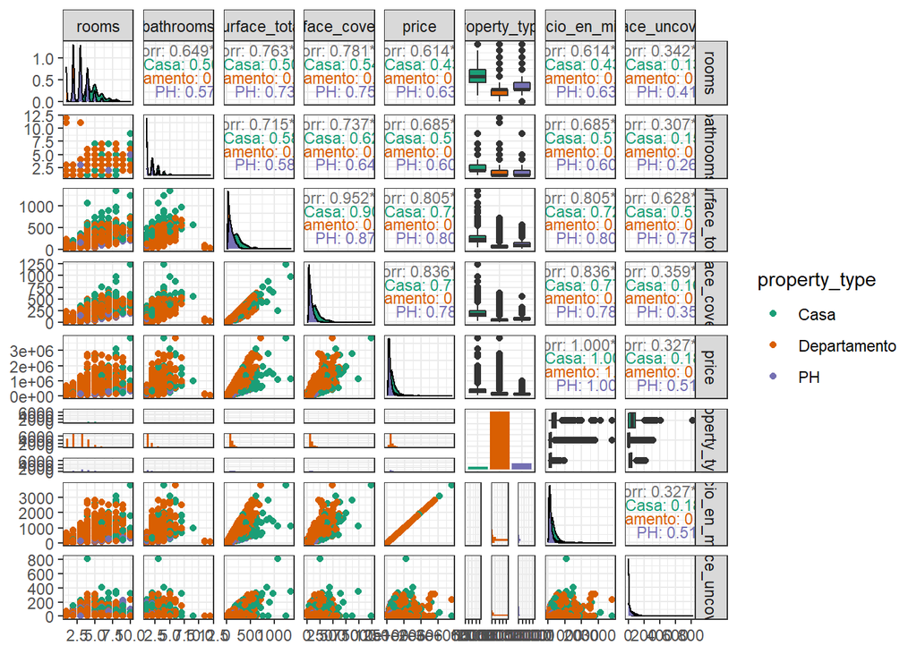

```r
# graficamos con ggpairs coloreando por property type
g <- ggpairs(datos_properati %>% select(-c(id,l3)), aes(color = property_type),
          upper = list(continuous = wrap("cor", size = 3, hjust=0.5)), legend = 25, progress=FALSE) +
  theme(axis.text.x = element_text(angle = 90, hjust = 1), legend.position = "bottom") +
  theme_bw()
# hacemos un loop para cambiar los colores del gráfico
for(i in 1:g$nrow) {
  for(j in 1:g$ncol){
    g[i,j] <- g[i,j] +
      scale_fill_brewer(palette="Dark2") +
      scale_color_brewer(palette="Dark2")
        }
}
g
```

### Particionar el dataset en entrenamiento y test

Partición en train 75% y test 25%

```r
# fijamos semilla
set.seed(22)
# Partición Train y Test, indicando proporción
train_test <- initial_split(datos_properati, prop = 0.75)
train_data <- training(train_test)
test_data <- testing(train_test)
# vemos las dimensiones de cada partición
train_data %>%
  dim_desc()
```

```
## [1] "[21,579 x 10]"
```

### Modelo de regresión multiple

Se tomo como referencia El modelo de regresión lineal multiple de properati de la catedra: https://github.com/eea-uba/EEA-2022

$E(precio)=\beta_0+\beta_1surface\_covered+\beta_2surface\_uncovered+\beta_3rooms+\beta_4bathrooms+\beta_5property_type+\beta_6l3$

```r
# Modelo multiple
# Modelo varias + barrios
modelo_varias <- lm(price ~ surface_covered + surface_uncovered + rooms + bathrooms + property_type + l3, data = train_data)
tidy_varias <- tidy(modelo_varias, conf.int = TRUE)
tidy_varias
```

| term | estimate | std.error | statistic | p.value | conf.low | conf.high |
| --- | --- | --- | --- | --- | --- | --- |
| (Intercept) | -259734.46526 | 13423.37032 | -1.934942e+01 | 1.040127e-82 | -2.860453e+05 | -233423.663 |
| surface_covered | 2940.33778 | 21.05196 | 1.396705e+02 | 0.000000e+00 | 2.899074e+03 | 2981.601 |
| surface_uncovered | 1016.91169 | 32.77626 | 3.102586e+01 | 8.569300e-207 | 9.526678e+02 | 1081.156 |
| rooms | -15669.91756 | 858.27054 | -1.825755e+01 | 6.516378e-74 | -1.735219e+04 | -13987.644 |
| bathrooms | 32944.68202 | 1387.96321 | 2.373599e+01 | 5.826212e-123 | 3.022417e+04 | 35665.193 |
| property_typeDepartamento | 209021.43989 | 4393.33951 | 4.757689e+01 | 0.000000e+00 | 2.004102e+05 | 217632.711 |
| property_typePH | 140156.81548 | 4608.65480 | 3.041165e+01 | 6.181188e-199 | 1.311235e+05 | 149190.121 |
| l3Agronomía | -2957.30860 | 19796.48998 | -1.493855e-01 | 8.812509e-01 | -4.175990e+04 | 35845.281 |
| l3Almagro | 404.76186 | 12972.86212 | 3.120066e-02 | 9.751098e-01 | -2.502301e+04 | 25832.535 |
| l3Balvanera | -19791.91455 | 13275.98087 | -1.490806e+00 | 1.360270e-01 | -4.581382e+04 | 6229.994 |

[output cut: 51 more lines]

#### Test F : evaluar significatividad global

Hipótesis:

- $H_0: β_1 = β_2 = · · · = β_{p−1} = 0$
- $H_1:$ no todos los $β_k$ ($k = 1, 2,..., p−1$) son iguales a 0.

```r
glance(modelo_varias)
```

| r.squared | adj.r.squared | sigma | statistic | p.value | df | logLik | AIC | BIC | deviance | df.residual | nobs |
| --- | --- | --- | --- | --- | --- | --- | --- | --- | --- | --- | --- |
| 0.7877694 | 0.7871776 | 99040.7 | 1331.195 | 0 | 60 | -278818.1 | 557760.3 | 558255 | 2.110713e+14 | 21518 | 21579 |

```r
summary(modelo_varias)
```

```
##
## Call:
## lm(formula = price ~ surface_covered + surface_uncovered + rooms +
##     bathrooms + property_type + l3, data = train_data)
##
## Residuals:
##      Min       1Q   Median       3Q      Max
## -1996915   -34455    -2332    26843  2071733
##
## Coefficients:
##                             Estimate Std. Error t value Pr(>|t|)
## (Intercept)               -259734.47   13423.37 -19.349  < 2e-16 ***
## surface_covered              2940.34      21.05 139.671  < 2e-16 ***
## surface_uncovered            1016.91      32.78  31.026  < 2e-16 ***
## rooms                      -15669.92     858.27 -18.258  < 2e-16 ***
## bathrooms                   32944.68    1387.96  23.736  < 2e-16 ***
## property_typeDepartamento  209021.44    4393.34  47.577  < 2e-16 ***
## property_typePH            140156.82    4608.65  30.412  < 2e-16 ***
## l3Agronomía                 -2957.31   19796.49  -0.149   0.8813
## l3Almagro                     404.76   12972.86   0.031   0.9751
## l3Balvanera                -19791.91   13275.98  -1.491   0.1360
## l3Barracas                  -9799.64   14107.46  -0.695   0.4873
## l3Barrio Norte              18774.55   13074.13   1.436   0.1510
## l3Belgrano                  58749.11   12769.89   4.601 4.24e-06 ***
## l3Boca                     -26615.84   16904.03  -1.575   0.1154
## l3Boedo                       -17.04   13934.29  -0.001   0.9990
## l3Caballito                  9751.15   12797.69   0.762   0.4461
## l3Catalinas                -78319.73   46051.81  -1.701   0.0890 .
## l3Centro / Microcentro      -9945.67   71153.68  -0.140   0.8888
## l3Chacarita                 13658.72   15165.42   0.901   0.3678
## l3Coghlan                   18785.93   14298.14   1.314   0.1889
## l3Colegiales                26352.73   13448.67   1.960   0.0501 .
## l3Congreso                 -25190.21   15365.75  -1.639   0.1011
## l3Constitución             -36602.67   16585.36  -2.207   0.0273 *
## l3Flores                   -23504.45   13127.00  -1.791   0.0734 .
## l3Floresta                 -17320.91   14105.40  -1.228   0.2195
## l3Liniers                    1664.04   15034.63   0.111   0.9119
## l3Mataderos                -14034.85   15566.32  -0.902   0.3673
## l3Monserrat                -24958.76   14294.22  -1.746   0.0808 .
## l3Monte Castro              -8383.36   15507.02  -0.541   0.5888
```

[output cut: 23 more lines]

```
## l3Villa General Mitre       -1816.65   16866.77  -0.108   0.9142
## l3Villa Lugano             -10173.50   17355.14  -0.586   0.5578
## l3Villa Luro                 7521.90   14579.78   0.516   0.6059
## l3Villa Ortuzar              8937.59   15203.71   0.588   0.5566
## l3Villa Pueyrredón          10991.53   14164.10   0.776   0.4377
## l3Villa Real                15426.87   21581.61   0.715   0.4747
## l3Villa Riachuelo             -36.40   42392.95  -0.001   0.9993
## l3Villa Santa Rita          -7955.14   15595.28  -0.510   0.6100
## l3Villa Urquiza             27421.71   12982.61   2.112   0.0347 *
## ---
## Signif. codes:  0 '***' 0.001 '**' 0.01 '*' 0.05 '.' 0.1 ' ' 1
##
## Residual standard error: 99040 on 21518 degrees of freedom
## Multiple R-squared:  0.7878, Adjusted R-squared:  0.7872
## F-statistic:  1331 on 60 and 21518 DF,  p-value: < 2.2e-16
```

#### Significatividad individual

Test para las $\beta_k$ Se pretende probar si el coeficiente de regresón de la variable es distinto de cero.

Hipótesis:

- $H_0:\beta_k = 0$
- $H_1:\beta_k ≠ 0$

```r
options("scipen"=1)
tidy_varias %>%
  select(term, statistic, p.value, conf.low, conf.high)
```

| term | statistic | p.value | conf.low | conf.high |
| --- | --- | --- | --- | --- |
| (Intercept) | -19.3494226095 | 1.040127e-82 | -286045.267602 | -233423.663 |
| surface_covered | 139.6705238128 | 0.000000e+00 | 2899.074385 | 2981.601 |
| surface_uncovered | 31.0258591548 | 8.569300e-207 | 952.667779 | 1081.156 |
| rooms | -18.2575503426 | 6.516378e-74 | -17352.191528 | -13987.644 |
| bathrooms | 23.7359907698 | 5.826212e-123 | 30224.171082 | 35665.193 |
| property_typeDepartamento | 47.5768921135 | 0.000000e+00 | 200410.168303 | 217632.711 |
| property_typePH | 30.4116540756 | 6.181188e-199 | 131123.509949 | 149190.121 |
| l3Agronomía | -0.1493855024 | 8.812509e-01 | -41759.898581 | 35845.281 |
| l3Almagro | 0.0312006601 | 9.751098e-01 | -25023.010960 | 25832.535 |
| l3Balvanera | -1.4908061965 | 1.360270e-01 | -45813.822617 | 6229.994 |

[output cut: 51 more lines]

Se grafica los coeficientes estimados y sus intervalos de confianza.

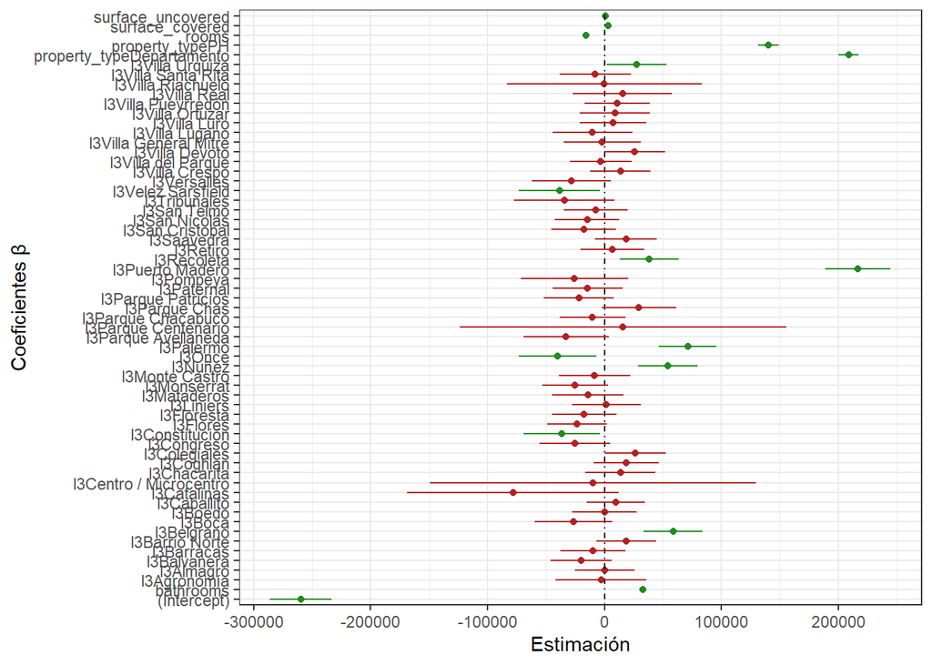

```r
# Gráfico de los Coeficientes
ggplot(tidy_varias, aes(estimate, term, color=p.value < 0.05, xmin = conf.low, xmax = conf.high, height = 0)) +
  geom_point() +
  geom_vline(xintercept = 0, lty = 4, color = "black") +
  geom_errorbarh() +
  scale_color_manual(values=c('firebrick', 'forestgreen')) +
  guides(color="none") +
  theme_bw() +
  labs(y = "Coeficientes β", x = "Estimación")
```

### Evaluación del modelo

```r
# Agregamos la predicciones al dataset de testeo
pred_varias = augment(modelo_varias, newdata = test_data)
pred_varias %>% select(l3,rooms, surface_covered, surface_uncovered, property_type, .fitted, .resid)
```

| l3 | rooms | surface_covered | surface_uncovered | property_type | .fitted | .resid |
| --- | --- | --- | --- | --- | --- | --- |
| Palermo | 1 | 35 | 3 | Departamento | 143684.797023 | -1.868480e+04 |
| Caballito | 1 | 36 | 19 | Departamento | 101486.375292 | -2.698638e+04 |
| Floresta | 1 | 33 | 3 | Departamento | 49322.707457 | 1.567729e+04 |
| Flores | 1 | 33 | 4 | Departamento | 44156.078565 | 1.494392e+04 |
| Flores | 1 | 33 | 4 | Departamento | 44156.078565 | 9.543921e+03 |
| Coghlan | 2 | 40 | 3 | Departamento | 90341.996655 | 5.658003e+03 |
| Paternal | 2 | 40 | 0 | Departamento | 54040.258449 | 9.597416e+02 |
| Monserrat | 2 | 43 | 0 | Departamento | 52367.587037 | 3.663241e+04 |
| Coghlan | 2 | 51 | 3 | Departamento | 122685.712267 | 1.314288e+03 |
| Nuñez | 2 | 43 | 8 | PH | 70943.807069 | 3.895619e+04 |

[output cut: 7184 more lines]

```r
# Listado de modelos
modelos_lineales = list(modelo_lineal_basico = modelo_varias)

# Realizamos predicciones en test
lista_predicciones_testing = map(.x = modelos_lineales, .f = augment, newdata = test_data)

# Obtenemos las métricas de performance en test
performance_modelos_lineales_test <- map_dfr(.x = lista_predicciones_testing, .f = metrics, truth = price, estimate = .fitted, .id="modelo") %>%
                                              filter(.metric!="rsq") %>%
                                              arrange(.metric, modelo) %>%
                                              mutate(.estimate= round(.estimate, digits = 2))
performance_modelos_lineales_test
```

| modelo | .metric | .estimator | .estimate |
| --- | --- | --- | --- |
| modelo_lineal_basico | mae | standard | 53240.49 |
| modelo_lineal_basico | rmse | standard | 101403.92 |

### Aplicación de Random Forest

Como feature engineering se aplica dummy a la variable barrios (l3) ya que al tomar solamente la variable barrio arrojaba demasiado error en la predicción. Por ejemplo que los barrios sean de Puerto Madero baja el precio de venta en dòlares en la explicaciòn del BreakDown.

```r
# Create dummy variable
train_data_d <- dummy_cols(train_data,
                                select_columns = "l3")
str(train_data_d)
```

```
## 'data.frame':    21579 obs. of  65 variables:
##  $ id                     : chr  "3ZTRccuKkerzZacwEqu5Ww==" "w4CylJDnRV1LDPVFUDhQ6Q==" "LCr4E+OxYd0aJcUojaq0VA==" "DU+IWE3DfhcZjC8GFpw3jA==" ...
##  $ l3                     : chr  "Villa Crespo" "Monte Castro" "Barrio Norte" "Villa Ortuzar" ...
##  $ rooms                  : int  2 2 5 1 2 2 4 2 3 2 ...
##  $ bathrooms              : int  1 1 2 1 1 1 2 1 1 1 ...
##  $ surface_total          : int  35 59 150 37 75 34 138 50 58 30 ...
##  $ surface_covered        : int  35 47 140 33 38 34 98 45 50 30 ...
##  $ price                  : int  71900 106000 298000 82000 105000 62000 185000 169000 118000 60000 ...
##  $ property_type          : chr  "Departamento" "Departamento" "Departamento" "Departamento" ...
##  $ precio_en_miles        : int  72 106 298 82 105 62 185 169 118 60 ...
##  $ surface_uncovered      : int  0 12 10 4 37 0 40 5 8 0 ...
##  $ l3_Abasto              : int  0 0 0 0 0 0 0 0 0 0 ...
##  $ l3_Agronomía           : int  0 0 0 0 0 0 0 0 0 0 ...
##  $ l3_Almagro             : int  0 0 0 0 0 0 0 0 0 0 ...
##  $ l3_Balvanera           : int  0 0 0 0 0 0 0 0 0 0 ...
```

[output cut: 51 more lines]

```r
test_data_d <- dummy_cols(test_data,
                                select_columns = "l3")
str(test_data_d)
```

```
## 'data.frame':    7194 obs. of  65 variables:
##  $ id                     : chr  "1ZHYJgyAbGUcX+v1Ggj1rA==" "BcAHh7UMLQpQ/axyyuwqkQ==" "t46/k2KlNgmLdXp0zyFnvg==" "T8M0Lvm7JO5gfhZ6iGv7Hg==" ...
##  $ l3                     : chr  "Palermo" "Caballito" "Floresta" "Flores" ...
##  $ rooms                  : int  1 1 1 1 1 2 2 2 2 2 ...
##  $ bathrooms              : int  1 1 1 1 1 1 1 1 1 1 ...
##  $ surface_total          : int  38 55 36 37 37 43 40 43 54 51 ...
##  $ surface_covered        : int  35 36 33 33 33 40 40 43 51 43 ...
##  $ price                  : int  125000 74500 65000 59100 53700 96000 55000 89000 124000 109900 ...
##  $ property_type          : chr  "Departamento" "Departamento" "Departamento" "Departamento" ...
##  $ precio_en_miles        : int  125 74 65 59 54 96 55 89 124 110 ...
##  $ surface_uncovered      : int  3 19 3 4 4 3 0 0 3 8 ...
##  $ l3_Abasto              : int  0 0 0 0 0 0 0 0 0 0 ...
##  $ l3_Agronomía           : int  0 0 0 0 0 0 0 0 0 0 ...
##  $ l3_Almagro             : int  0 0 0 0 0 0 0 0 0 0 ...
##  $ l3_Balvanera           : int  0 0 0 0 0 0 0 0 0 0 ...
```

[output cut: 51 more lines]

```r
#Corrijo los nombres de las columnas, para que los tome RandomForest:
#1 Elimino espacioes en Blanco:
for (col in colnames(train_data_d )){
  setnames(train_data_d , col , str_remove_all(col, " "))
}
for (col in colnames(test_data_d )){
  setnames(test_data_d , col , str_remove_all(col, " "))
}

#2 Elimino /:
setnames(train_data_d , "l3_Centro/Microcentro" , "l3_CentroMicrocentro")
setnames(test_data_d , "l3_Centro/Microcentro" , "l3_CentroMicrocentro")

#3 Quito las columnas que NO voy a usar: l3, precio_en_miles, surface_total
train_data_d <- train_data_d %>% select(-c(l3, surface_total, precio_en_miles))
test_data_d <- test_data_d %>% select(-c(l3, surface_total, precio_en_miles))
```

Se entrenan los datos con RandomForest

```r
modelo_randomForest <- randomForest(price ~.-id, data = train_data_d)
```

```r
precio_train <- train_data_d %>% select(price) %>% as.matrix()
precio_test <- test_data_d %>% select(price) %>% as.matrix()
```

Se obtienen los valores de MAE y RMSE

```r
# Función augment para RF
augment_RF <- function(modelo_red, matriz_variables, variable_target) {
  y_pred <- predict(modelo_red, matriz_variables, verbose=0) %>% as.vector()
  df_predicciones <- tibble(y = as.vector(variable_target), y_pred = y_pred) %>%
                      mutate(residuo=y-y_pred)
  return(df_predicciones)
}
```

```r
performance_RF<-augment_RF(modelo_randomForest, test_data_d , precio_test) %>%
  metrics(truth = y, estimate = y_pred) %>%
  filter(.metric!="rsq") %>%
  arrange(.metric) %>%
  mutate(.estimate= round(.estimate, digits = 2))
performance_RF
```

| .metric | .estimator | .estimate |
| --- | --- | --- |
| mae | standard | 38116.90 |
| rmse | standard | 73836.71 |

### Break down

Primero se aplica la función explain de la librería Dalex.

```r
explain_rf <- DALEX::explain(model = modelo_randomForest,
                        data = train_data_d,
                           y = precio_train,
                       label = "Random Forest")
```

```
## Preparation of a new explainer is initiated
##   -> model label       :  Random Forest
##   -> data              :  21579  rows  62  cols
##   -> target variable   :  21579  values
##   -> predict function  :  yhat.randomForest  will be used (  default  )
##   -> predicted values  :  No value for predict function target column. (  default  )
##   -> model_info        :  package randomForest , ver. 4.7.1.1 , task regression (  default  )
##   -> predicted values  :  numerical, min =  28698.42 , mean =  204666.8 , max =  2641469
##   -> residual function :  difference between y and yhat (  default  )
##   -> residuals         :  numerical, min =  -580932.9 , mean =  -343.5688 , max =  1195660
##   A new explainer has been created!
```

#### Predict_parts

Primero se selecciona una nueva observación del test_data. En este caso un departamento del barrio de Puerto Madero, de 90 metros cuadrados cubiertos, 55 descubiertos, con 3 habitaciones y 2 baños.

```r
#selecciono observacion_1: en Puerto Madero
#variables_test <- test_data_d %>% select(-c(l3, surface_total, price, precio_en_miles))

variable_ya<-filter(test_data_d, l3_PuertoMadero == 1) #filtra el barrio

variable_y<-variable_ya[9,] #selecciona la n° 9 de ese barrio
variable_y
```

|  | id | rooms | bathrooms | surface_covered | price | property_type | surface_uncovered | l3_Abasto | l3_Agronomía | l3_Almagro | l3_Balvanera | l3_Barracas | l3_BarrioNorte | l3_Belgrano | l3_Boca | l3_Boedo | l3_Caballito | l3_Catalinas | l3_CentroMicrocentro | l3_Chacarita | l3_Coghlan | l3_Colegiales | l3_Congreso | l3_Constitución | l3_Flores | l3_Floresta | l3_Liniers | l3_Mataderos | l3_Monserrat | … |
| --- | --- | --- | --- | --- | --- | --- | --- | --- | --- | --- | --- | --- | --- | --- | --- | --- | --- | --- | --- | --- | --- | --- | --- | --- | --- | --- | --- | --- | --- | --- |
| 9 | Umep+JAU2pICzM/txsl+xA== | 3 | 2 | 90 | 750000 | Departamento | 55 | 0 | 0 | 0 | 0 | 0 | 0 | 0 | 0 | 0 | 0 | 0 | 0 | 0 | 0 | 0 | 0 | 0 | 0 | 0 | 0 | 0 | 0 | … |

Se aplica la función predict_parts para obtener la predicción de cada variable.

```r
bd_rf <- predict_parts(explainer = explain_rf,
                 new_observation = variable_y,
                            type = "break_down")
bd_rf
```

| variable | contribution | variable_name | variable_value | cumulative | sign | position | label |
| --- | --- | --- | --- | --- | --- | --- | --- |
| intercept | 2.046668e+05 | intercept | 1 | 204666.8 | 1 | 64 | Random Forest |
| l3_PuertoMadero = 1 | 1.089537e+05 | l3_PuertoMadero | 1 | 313620.4 | 1 | 63 | Random Forest |
| surface_uncovered = 55 | 1.274064e+04 | surface_uncovered | 55 | 326361.1 | 1 | 62 | Random Forest |
| surface_covered = 90 | 4.549931e+04 | surface_covered | 90 | 371860.4 | 1 | 61 | Random Forest |
| bathrooms = 2 | 2.510730e+04 | bathrooms | 2 | 396967.7 | 1 | 60 | Random Forest |
| l3_Palermo = 0 | 3.668281e+03 | l3_Palermo | 0 | 400636.0 | 1 | 59 | Random Forest |
| l3_Belgrano = 0 | 3.212485e+03 | l3_Belgrano | 0 | 403848.5 | 1 | 58 | Random Forest |
| property_type = Departamento | -8.213506e+03 | property_type | Departamento | 395635.0 | -1 | 57 | Random Forest |
| l3_Recoleta = 0 | 2.080083e+02 | l3_Recoleta | 0 | 395843.0 | 1 | 56 | Random Forest |
| l3_Nuñez = 0 | 3.252757e+02 | l3_Nuñez | 0 | 396168.2 | 1 | 55 | Random Forest |

[output cut: 54 more lines]

Se grafican las contribuciones de cada variable.

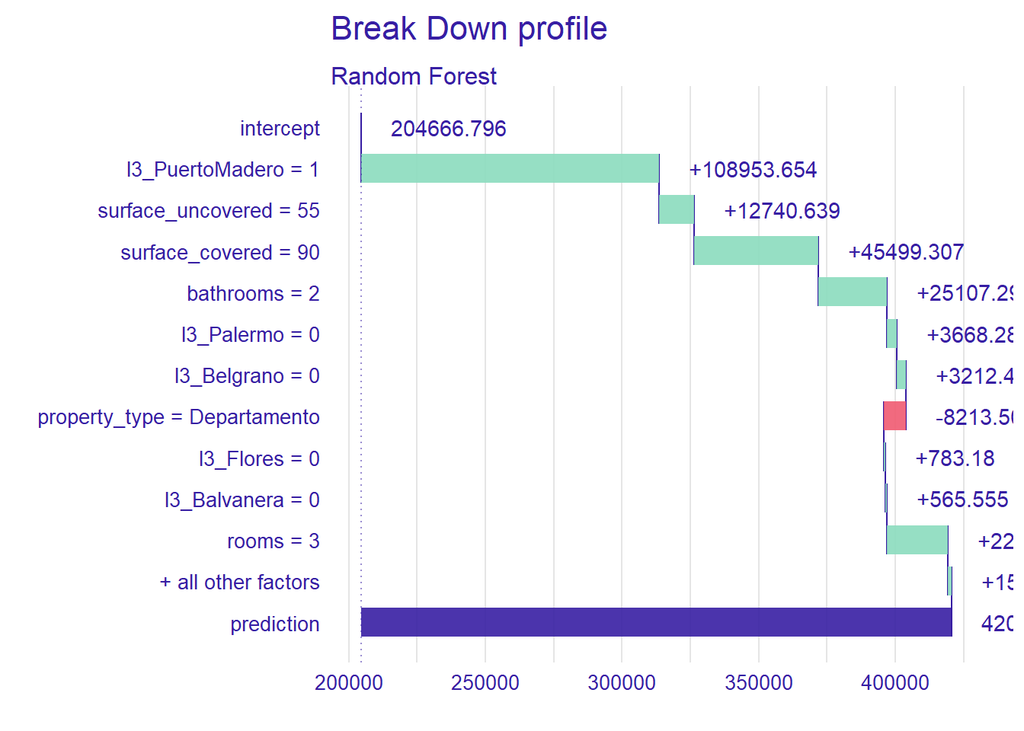

```r
plot(bd_rf)
```

#### Paso a Paso del Break Down

Valor del intercept: se obtiene a partir del promedio de las predicciones de los datos de entrenamiento.

```r
#0: intercept: El valor medio de la predicción de daata train
mean(predict(modelo_randomForest, train_data_d))
```

```
## [1] 204666.8
```

En Primer lugar se ordenan las variables. EL criterio a utilizar es obtener un score y ordenarlos de forma decreciento. El score de cada variable se obtiene fijando el valor de la variable de la nueva observación en todo el data train. Se obtiene el promedio de de las predicciones del train al cambiar los valores de la variable por el de la nueva observacón. Después se obtiene la diferencia entre dicho promedio de predicción y el promedio de las predicciones de los datos de entrenamiento originales en valor absoluto. Se repite para cada variable y se las ordena de forma decreciente,

l3_PuertoMadero

```r
score<-{}
data_train_l3_PurertoMadero<- train_data_d
data_train_l3_PurertoMadero$l3_PuertoMadero<-variable_y$l3_PuertoMadero # Fijo el valor de la variable de la nueva obvervación en el data train
mean(predict(modelo_randomForest, data_train_l3_PurertoMadero))# El promedio de las predicciones al fijar la variable
```

```
## [1] 313620.4
```

```r
delta_l3_PuertoMAdero<-abs(mean(predict(modelo_randomForest, data_train_l3_PurertoMadero))-mean(predict(modelo_randomForest, train_data_d)))
delta_l3_PuertoMAdero# Score para l3_Puerto madero
```

```
## [1] 108953.7
```

```r
score[['l3_PuertoMAdero']]<-delta_l3_PuertoMAdero
```

surface_uncovered

```r
data_train_surface_uncovered<- train_data_d
data_train_surface_uncovered$surface_uncovered<-variable_y$surface_uncovered # Se coloca el valor de la variable  de la nueva obvervación en todos los datos del data train
mean(predict(modelo_randomForest, data_train_surface_uncovered))# El promedio de las predicciones al fijar la variable.
```

```
## [1] 231006.7
```

```r
delta_surface_uncovered<-abs(mean(predict(modelo_randomForest, data_train_surface_uncovered))-mean(predict(modelo_randomForest, train_data_d)))
delta_surface_uncovered# Score para surface_uncovered
```

```
## [1] 26339.93
```

```r
score[['surface_uncovered']]<-delta_surface_uncovered
score
```

```
## $l3_PuertoMAdero
## [1] 108953.7
##
## $surface_uncovered
## [1] 26339.93
```

surface_covered

```r
data_train_surface_covered<- train_data_d
data_train_surface_covered$surface_covered<-variable_y$surface_covered # Se coloca el valor de la variable de la nueva obvervación en todos los datos del data train
mean(predict(modelo_randomForest, data_train_surface_covered))# El promedio de las predicciones al fijar la variable.
```

```
## [1] 219573.1
```

```r
delta_surface_covered<-abs(mean(predict(modelo_randomForest, data_train_surface_covered))-mean(predict(modelo_randomForest, train_data_d)))
delta_surface_covered# surface_covered
```

```
## [1] 14906.27
```

```r
score[['surface_covered']]<-delta_surface_uncovered
```

bathrooms

```r
data_train_bathrooms<- train_data_d
data_train_bathrooms$bathrooms<-variable_y$bathrooms # Se coloca el valor de la variable de la nueva obvervación en todos los datos del data train
mean(predict(modelo_randomForest, data_train_bathrooms))# El promedio de las predicciones al fijar la variable
```

```
## [1] 216991.6
```

```r
delta_bathrooms<-abs(mean(predict(modelo_randomForest, data_train_bathrooms))-mean(predict(modelo_randomForest, train_data_d)))
delta_bathrooms# Score para bathrooms
```

```
## [1] 12324.78
```

```r
score[['bathrooms']]<-delta_bathrooms
```

l3_Palermo

```r
data_train_l3_Palermo<- train_data_d
data_train_l3_Palermo$l3_Palermo<-variable_y$l3_Palermo # Se coloca el valor de la variable de la nueva obvervación en todos los datos del data train
mean(predict(modelo_randomForest, data_train_l3_Palermo))# El promedio de las predicciones al fijar la variable
```

```
## [1] 193188.4
```

```r
delta_l3_Palermo<-abs(mean(predict(modelo_randomForest, data_train_l3_Palermo))-mean(predict(modelo_randomForest, train_data_d)))
delta_l3_Palermo# Score para l3_Palermo
```

```
## [1] 11478.39
```

```r
score[['l3_Palermo']]<-delta_l3_Palermo
```

l3_Belgrano

```r
data_train_l3_Belgrano<- train_data_d
data_train_l3_Belgrano$l3_Belgrano<-variable_y$l3_Belgrano # Se coloca el valor de la variable de la nueva obvervación en todos los datos del data train
mean(predict(modelo_randomForest, data_train_l3_Belgrano))# El promedio de las predicciones al fijar la variable
```

```
## [1] 198281.6
```

```r
delta_l3_Belgrano<-abs(mean(predict(modelo_randomForest, data_train_l3_Belgrano))-mean(predict(modelo_randomForest, train_data_d)))
delta_l3_Belgrano # Score para l3_Belgrano
```

```
## [1] 6385.169
```

```r
score[['l3_Belgrano']]<-delta_l3_Belgrano
```

property_type

```r
data_train_property_type<- train_data_d
data_train_property_type$property_type<-variable_y$property_type # Se coloca el valor de la variable de la nueva obvervación en todos los datos del data train
mean(predict(modelo_randomForest, data_train_property_type))# El promedio de las predicciones al fijar la variable
```

```
## [1] 200659.3
```

```r
delta_property_type<-abs(mean(predict(modelo_randomForest, data_train_property_type))-mean(predict(modelo_randomForest, train_data_d)))
delta_property_type# Score para property_type
```

```
## [1] 4007.536
```

```r
score[['property_type']]<-delta_property_type
```

l3_Flores

```r
data_train_l3_Flores<- train_data_d
data_train_l3_Flores$l3_Flores<-variable_y$l3_Flores # Se coloca el valor de la variable de la nueva obvervación en todos los datos del data train
mean(predict(modelo_randomForest, data_train_l3_Flores))#El promedio de las predicciones al fijar la variable
```

```
## [1] 205171.8
```

```r
delta_l3_Flores<-abs(mean(predict(modelo_randomForest, data_train_l3_Flores))-mean(predict(modelo_randomForest, train_data_d)))
delta_l3_Flores # Score para l3_Flores
```

```
## [1] 505.0171
```

```r
score[['l3_Flores']]<-delta_l3_Flores
```

l3_Balvanera

```r
data_train_l3_Balvanera<- train_data_d
data_train_l3_Balvanera$l3_Balvanera<-variable_y$l3_Balvanera # Se coloca el valor de la variable de la nueva obvervación en todos los datos del data train
mean(predict(modelo_randomForest, data_train_l3_Balvanera))#El promedio de las predicciones al fijar la variable
```

```
## [1] 205108.4
```

```r
delta_l3_Balvanera<-abs(mean(predict(modelo_randomForest, data_train_l3_Balvanera))-mean(predict(modelo_randomForest, train_data_d)))
delta_l3_Balvanera # Score para l3_Flores
```

```
## [1] 441.64
```

```r
score[['l3_Balvanera']]<-delta_l3_Balvanera
```

rooms

```r
data_train_rooms<- train_data_d
data_train_rooms$rooms<-variable_y$rooms # Se coloca el valor de la variable de la nueva obvervación en todos los datos del data train
mean(predict(modelo_randomForest, data_train_rooms))# El promedio de las predicciones al fijar la variable
```

```
## [1] 204686.8
```

```r
delta_rooms<-abs(mean(predict(modelo_randomForest, data_train_rooms))-mean(predict(modelo_randomForest, train_data_d)))
delta_rooms # Score para rooms
```

```
## [1] 20.03398
```

```r
score[['rooms']]<-delta_rooms
```

El segundo paso es obtener las contribuciones de acuerdo al orden ya establecido. Para esto vamos a fijar los valores de las variables de a una a la vez con el valor de la variable en la nueva observación. Obtenemos las predicciones condicionada a la variable y el promedio de las mismas. Luego tambien se fija la segunda variable y manteniendo fija la anterior también. Se obtiene la contribución de forma aditiva. Se repite el procedimiento para todas las variables. Al final vamos a obtener que todas las predicciones del train son iguales a la nueva observación. Por lo tanto converge en el valor de la predicción de la nueva observación.

Contribución de l3_PuertoMadero

```r
Contribuciones<-{}
data_train_breakdown<- train_data_d
data_train_breakdown$l3_PuertoMadero<-variable_y$l3_PuertoMadero # Fijo el valor de la variable de la nueva obvervación en el data train
Acc=mean(predict(modelo_randomForest, data_train_breakdown))# El promedio de las predicciones al decir que todas las propiedades del train son de puerto madero.
Acc
```

```
## [1] 313620.4
```

```r
delta_l3_PuertoMAdero<-abs(mean(predict(modelo_randomForest, data_train_breakdown))-mean(predict(modelo_randomForest, train_data_d)))
delta_l3_PuertoMAdero# Contribución de l3_PuertoMadero
```

```
## [1] 108953.7
```

```r
Contribuciones[['l3_PuertoMAdero']]<-delta_l3_PuertoMAdero
```

Contribución de surface_uncovered

```r
data_train_breakdown$surface_uncovered<-variable_y$surface_uncovered # Fijo el valor de la variable  de la nueva obvervación en el data train
mean(predict(modelo_randomForest, data_train_breakdown))# El promedio de las predicciones al decir que todas las propiedades del train son de puerto madero y tienen superficie descubierta de 55 metros cuadrados
```

```
## [1] 326361.1
```

```r
delta_surface_uncovered<-abs(mean(predict(modelo_randomForest, data_train_breakdown)-Acc))
Acc<-mean(predict(modelo_randomForest, data_train_breakdown))
delta_surface_uncovered# Contribución de surface_uncovered
```

```
## [1] 12740.64
```

```r
Contribuciones[['surface_uncovered']]<-delta_surface_uncovered
```

Contribución de surface_covered

```r
data_train_breakdown$surface_covered<-variable_y$surface_covered # Fijo el valor de la variable de la nueva obvervación en el data train
mean(predict(modelo_randomForest, data_train_breakdown))# El promedio de las predicciones al decir que todas las propiedades del train son de puerto madero, con superficie descubierta de 55 metros cuadrados, con superficie cubierta de 90 metros cuadrados
```

```
## [1] 371860.4
```

```r
delta_surface_covered<-abs(mean(predict(modelo_randomForest, data_train_breakdown)-Acc))
Acc<-mean(predict(modelo_randomForest, data_train_breakdown))
delta_surface_covered# Contribución de superficie cubierta
```

```
## [1] 45499.31
```

```r
Contribuciones[['surface_covered']]<-delta_surface_covered
```

Contribución de bathrooms

```r
data_train_breakdown$bathrooms<-variable_y$bathrooms # Fijo el valor de la variable de la nueva obvervación en el data train
mean(predict(modelo_randomForest, data_train_breakdown))# El promedio de las predicciones al decir que todas las propiedades del train son de puerto madero, con superficie descubierta de 55 metros cuadrados, con superficie cubierta de 90 metros cuadrados, con dos baños.
```

```
## [1] 396967.7
```

```r
delta_bathrooms<-abs(mean(predict(modelo_randomForest, data_train_breakdown)-Acc))
Acc<-mean(predict(modelo_randomForest, data_train_breakdown))
delta_bathrooms# Contribución de Bathrooms
```

```
## [1] 25107.3
```

```r
Contribuciones[['bathrooms']]<-delta_bathrooms
```

Contribución de l3_Palermo

```r
data_train_breakdown$l3_Palermo<-variable_y$l3_Palermo # Fijo el valor de la variable de la nueva obvervación en el data train
mean(predict(modelo_randomForest, data_train_breakdown))# El promedio de las predicciones al decir que todas las propiedades del train son de puerto madero, con superficie descubierta de 55 metros cuadrados, con superficie cubierta de 90 metros cuadrados, con dos baños y no ser de palermo,
```

```
## [1] 400636
```

```r
delta_l3_Palermo<-abs(mean(predict(modelo_randomForest, data_train_breakdown)-Acc))
Acc<-mean(predict(modelo_randomForest, data_train_breakdown))
delta_l3_Palermo# Contribución de l3_Palermo
```

```
## [1] 3668.281
```

```r
Contribuciones[['l3_Palermo']]<-delta_l3_Palermo
```

Contribución de l3_Belgrano

```r
data_train_breakdown$l3_Belgrano<-variable_y$l3_Belgrano # Fijo el valor de la variable de la nueva obvervación en el data train
mean(predict(modelo_randomForest, data_train_breakdown))#El promedio de las predicciones al decir que todas las propiedades del train son de puerto madero, con superficie descubierta de 55 metros cuadrados, con superficie cubierta de 90 metros cuadrados, con dos baños y no son de palermo, no son de Belgrano
```

```
## [1] 403848.5
```

```r
delta_l3_Belgrano<-abs(mean(predict(modelo_randomForest, data_train_breakdown)-Acc))
Acc<-mean(predict(modelo_randomForest, data_train_breakdown))
delta_l3_Belgrano# Contribución de l3_Belgrano
```

```
## [1] 3212.485
```

```r
Contribuciones[['l3_Belgrano']]<-delta_l3_Belgrano
```

Contribución de property_type

```r
data_train_breakdown$property_type<-variable_y$property_type # Fijo el valor de la variable  de la nueva obvervación en el data train
mean(predict(modelo_randomForest, data_train_breakdown))#El promedio de las predicciones al decir que todas las propiedades del train son de puerto madero, con superficie descubierta de 55 metros cuadrados, con superficie cubierta de 90 metros cuadrados, con dos baños y no son de palermo, no son de Belgrano y son departamentos
```

```
## [1] 395635
```

```r
delta_property_type<-mean(predict(modelo_randomForest, data_train_breakdown))-Acc
Acc<-mean(predict(modelo_randomForest, data_train_breakdown))
delta_property_type# Contribución de tipo de propiedad
```

```
## [1] -8213.506
```

```r
Contribuciones[['property_type']]<-delta_property_type
```

Contribución de l3_Flores

```r
data_train_breakdown$l3_Recoleta<-variable_y$l3_Recoleta
data_train_breakdown$l3_Nuñez<-variable_y$l3_Nuñez
data_train_breakdown$l3_BarrioNorte<-variable_y$l3_BarrioNorte
data_train_breakdown$l3_Caballito<-variable_y$l3_Caballito
data_train_breakdown$l3_VillaUrquiza<-variable_y$l3_VillaUrquiza
data_train_breakdown$l3_Colegiales<-variable_y$l3_Colegiales
Acc<-mean(predict(modelo_randomForest, data_train_breakdown))
data_train_breakdown$l3_Flores<-variable_y$l3_Flores # Fijo el valor de la variable de la nueva obvervación en el data train
mean(predict(modelo_randomForest, data_train_breakdown))
```

```
## [1] 396945.6
```

```r
delta_l3_Flores<-mean(predict(modelo_randomForest, data_train_breakdown))-Acc
Acc<-mean(predict(modelo_randomForest, data_train_breakdown))
delta_l3_Flores# Contribución de l3_flores
```

```
## [1] 783.1796
```

```r
Contribuciones[['l3_Flores']]<-delta_l3_Flores
```

Contribución de l3_Balvanera

```r
data_train_breakdown$l3_VillaDevoto<-variable_y$l3_VillaDevoto
Acc<-mean(predict(modelo_randomForest, data_train_breakdown))
data_train_breakdown$l3_Balvanera<-variable_y$l3_Balvanera # Fijo el valor de la variable de la nueva obvervación en el data train
mean(predict(modelo_randomForest, data_train_breakdown))
```

```
## [1] 397524.4
```

```r
delta_l3_Balvanera<-mean(predict(modelo_randomForest, data_train_breakdown))-Acc
Acc<-mean(predict(modelo_randomForest, data_train_breakdown))
delta_l3_Balvanera# Contribución de l3_almagro
```

```
## [1] 565.5553
```

```r
Contribuciones[['Balvanera']]<-delta_l3_Balvanera
```

Contribución de rooms

```r
data_train_breakdown$l3_Retiro<-variable_y$l3_Retiro
data_train_breakdown$l3_VillaCrespo<-variable_y$l3_VillaCrespo
data_train_breakdown$l3_Saavedra<-variable_y$l3_Saavedra
data_train_breakdown$l3_SanCristobal<-variable_y$l3_SanCristobal
data_train_breakdown$l3_Floresta<-variable_y$l3_Floresta
data_train_breakdown$l3_Monserrat<-variable_y$l3_Monserrat
data_train_breakdown$l3_Almagro<-variable_y$l3_Almagro
data_train_breakdown$l3_Coghlan<-variable_y$l3_Coghlan
data_train_breakdown$l3_Constitución<-variable_y$l3_Constitución
data_train_breakdown$l3_Mataderos<-variable_y$l3_Mataderos
data_train_breakdown$l3_Boca<-variable_y$l3_Boca
data_train_breakdown$l3_Congreso<-variable_y$l3_Congreso
data_train_breakdown$l3_ParquePatricios<-variable_y$l3_ParquePatricios
data_train_breakdown$l3_Once<-variable_y$l3_Once
data_train_breakdown$l3_SanNicolás<-variable_y$l3_SanNicolás
data_train_breakdown$l3_Paternal<-variable_y$l3_Paternal
data_train_breakdown$l3_VillaLugano<-variable_y$l3_VillaLugano
data_train_breakdown$l3_Chacarita<-variable_y$l3_Chacarita
data_train_breakdown$l3_Boedo<-variable_y$l3_Boedo
data_train_breakdown$l3_ParqueChacabuco<-variable_y$l3_ParqueChacabuco
data_train_breakdown$l3_VelezSarsfield<-variable_y$l3_VelezSarsfield
data_train_breakdown$l3_ParqueAvellaneda<-variable_y$l3_ParqueAvellaneda
data_train_breakdown$l3_MonteCastro<-variable_y$l3_MonteCastro
data_train_breakdown$l3_Barracas<-variable_y$l3_Barracas
data_train_breakdown$l3_VillaSantaRita<-variable_y$l3_VillaSantaRita
data_train_breakdown$l3_VilladelParque<-variable_y$l3_VilladelParque
data_train_breakdown$l3_Liniers<-variable_y$l3_Liniers
data_train_breakdown$l3_SanTelmo<-variable_y$l3_SanTelmo
data_train_breakdown$l3_Pompeya<-variable_y$l3_Pompeya
data_train_breakdown$l3_VillaPueyrredón<-variable_y$l3_VillaPueyrredón
data_train_breakdown$l3_Versalles<-variable_y$l3_Versalles
Acc<-mean(predict(modelo_randomForest, data_train_breakdown))
data_train_breakdown$rooms<-variable_y$rooms # Fijo el valor de la variable de la nueva obvervación en el data train
mean(predict(modelo_randomForest, data_train_breakdown))
```

```
## [1] 420694.1
```

```r
delta_rooms<-mean(predict(modelo_randomForest, data_train_breakdown))-Acc
Acc<-mean(predict(modelo_randomForest, data_train_breakdown))
delta_rooms# Contribución de ambientes
```

```
## [1] 22210.23
```

```r
Contribuciones[['rooms']]<-delta_rooms
```

```r
Contribuciones
```

```
## $l3_PuertoMAdero
## [1] 108953.7
##
## $surface_uncovered
## [1] 12740.64
##
## $surface_covered
## [1] 45499.31
##
## $bathrooms
## [1] 25107.3
##
## $l3_Palermo
## [1] 3668.281
##
## $l3_Belgrano
## [1] 3212.485
##
## $property_type
## [1] -8213.506
##
## $l3_Flores
## [1] 783.1796
##
## $Balvanera
## [1] 565.5553
##
## $rooms
## [1] 22210.23
```

#### Cambiar el orden

Se puede determinar el orden de las variables manualmente utilizando el parámetro “order”. En este ejemplo al cambiar el orden de las variables cambia el valor de las contribuciones. Por lo tanto es aconsejable utilizar ibreakdown que tienen en cuenta las iteraciones entre variables.

```r
bd_o_rf <- predict_parts(explainer = explain_rf,
                 new_observation = variable_y,
                 order = c("surface_uncovered","bathrooms","surface_covered","l3","property_type" , "rooms", "l3_PuertoMadero", "l3_Belgrano", "l3_Nuñez", "l3_Flores", "l3_Recoleta"),
                 type = "break_down")
bd_o_rf
```

| variable | contribution | variable_name | variable_value | cumulative | sign | position | label |
| --- | --- | --- | --- | --- | --- | --- | --- |
| intercept | 204666.7959 | intercept | 1 | 204666.8 | 1 | 12 | Random Forest |
| surface_uncovered = 55 | 26339.9310 | surface_uncovered | 55 | 231006.7 | 1 | 11 | Random Forest |
| bathrooms = 2 | 16819.9781 | bathrooms | 2 | 247826.7 | 1 | 10 | Random Forest |
| surface_covered = 90 | 16927.2161 | surface_covered | 90 | 264753.9 | 1 | 9 | Random Forest |
| property_type = Departamento | 699.8579 | property_type | Departamento | 265453.8 | 1 | 8 | Random Forest |
| rooms = 3 | 1963.4504 | rooms | 3 | 267417.2 | 1 | 7 | Random Forest |
| l3_PuertoMadero = 1 | 144965.2319 | l3_PuertoMadero | 1 | 412382.5 | 1 | 6 | Random Forest |
| l3_Belgrano = 0 | 2704.2106 | l3_Belgrano | 0 | 415086.7 | 1 | 5 | Random Forest |
| l3_Nuñez = 0 | 508.4036 | l3_Nuñez | 0 | 415595.1 | 1 | 4 | Random Forest |
| l3_Flores = 0 | 740.3042 | l3_Flores | 0 | 416335.4 | 1 | 3 | Random Forest |

[output cut: 2 more lines]

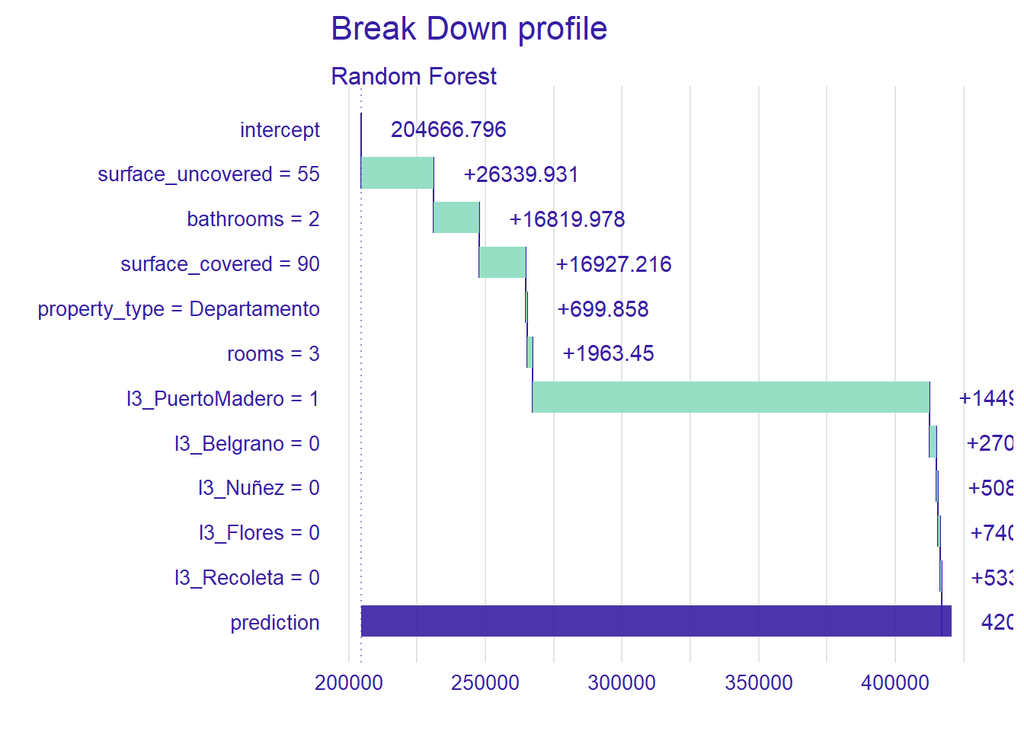

```r
plot(bd_o_rf)
```